# Ejemplo del entregable 2

Evelia Coss

2025-03-04

## Descripción de los datos

Tabla 1: Detalles del Bioproyecto y características de las muestras

| Descripción | Información |
| --- | --- |
| Bioproject | [PRJNA1051620](https://www.ncbi.nlm.nih.gov/geo/query/acc.cgi?acc=GSE250023) |
| Especie | *Homo sapiens* |
| Tipo de bibliotecas | *paired-end* |
| Método de selección | RNA total |
| Número de transcriptomas | 6 |
| Número de réplicas biológicas | 3 réplicas biológicas por condición (SLE_R y SLE_NR) |
| Secuenciador empleado | DNBSEQ-G400 platform |
| Profundidad de secuenciación de cada transcriptoma | 33 M seq a 66 M seq |
| Tamaño de las lecturas | 150 bp |
| Artículo científico | [Kavita, *et al*. 2024. Impaired innate and adaptive immune responses to BNT162b2 SARS-CoV-2 vaccination in systemic lupus erythematosus. *JCIinsight*](https://insight.jci.org/articles/view/176556) |

El articulo de “Impaired innate and adaptive immune responses to BNT162b2 SARS-CoV-2 vaccination in systemic lupus erythematosus” analiza las respuestas inmunitarias innatas y adaptativas a la vacunación contra COVID-19 en pacientes con lupus eritematoso sistémico (SLE) comparados con un grupo de control de personas sanas. El estudio clasifica las respuestas de los pacientes en dos grupos: “Respuesta (R, SLE_R)” y “Sin Respuesta (NR, SLE_NR)”, teniendo en cuenta tanto la efectividad de la respuesta inmunitaria a la vacunación como la presencia de autoanticuerpos específicos, como los anti-Ro52 y anti-Ro60.

Para fines de esta práctica, se seleccionaron las muestras correspondientes al **día 7** posterior a la vacunación contra COVID-19 (BNT162b2 SARS-CoV-2) en pacientes con lupus, las cuales se presentan en la **Tabla 2**.

| individuos | muestras | condicion | respuesta | tiempos | BioSample | replica_biologica |
| --- | --- | --- | --- | --- | --- | --- |
| 1 | S003 | SLE_R | R | 7 | SAMN38793001 | SLE_R_1 |
| 8 | S008 | SLE_R | R | 7 | SAMN38792997 | SLE_R_2 |
| 14 | S018 | SLE_R | R | 7 | SAMN38792988 | SLE_R_3 |
| 12 | S013 | SLE_NR | NR | 7 | SAMN38792993 | SLE_NR_1 |
| 17 | S023 | SLE_NR | NR | 7 | SAMN38792983 | SLE_NR_2 |
| 18 | S028 | SLE_NR | NR | 7 | SAMN38792978 | SLE_NR_3 |

Los datos se pueden descargar usando [ENA](https://www.ebi.ac.uk/ena/browser/view/PRJNA1051620).

## Calidad de las secuencias de los datos crudos

> NOTA: Las siguientes figuras son solo representaciones, no son los resultados de este estudio.

Se analizó la calidad de las secuencias en los datos crudos, obteniendo un contenido de GC de aproximadamente 50% y una profundidad de lectura en un rango de 33 M a 66 M secuencias.

Las muestras presentan una calidad óptima, con valores dentro de la zona verde y un puntaje Phred superior a 30. Del mismo modo, las muestras mostraron un promedio de calidad con un pico máximo en Phred 35.

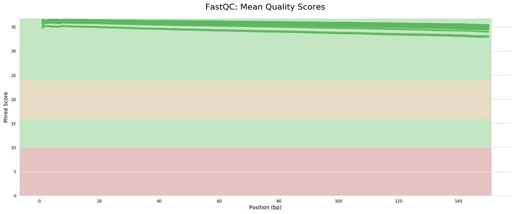

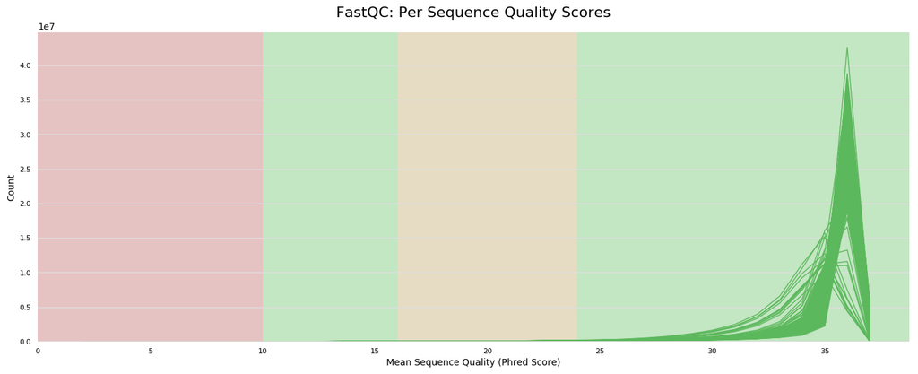

Calidad de las secuencias en muestras SLE y controles

Se identificaron varios picos en el %GC lo cual puede relacionarse con contaminacion en las muestras.

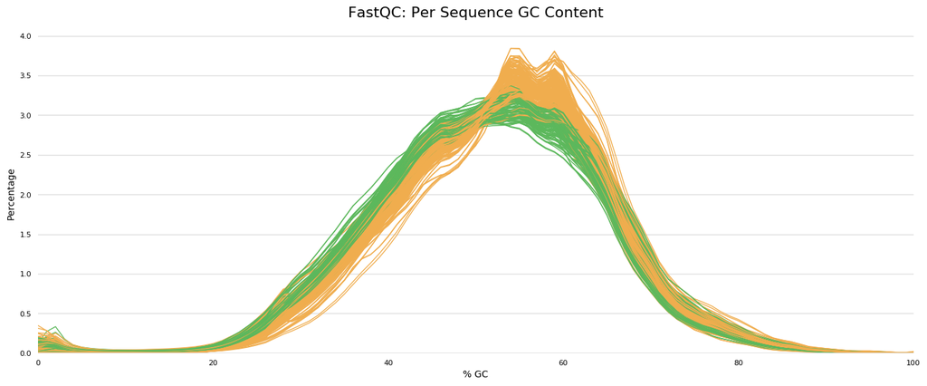

Variaciones en el porcentaje de %GC en las muestras

Se identificaron secuencias duplicadas, posiblemente relacionadas con la presencia de dimeros de adaptadores.

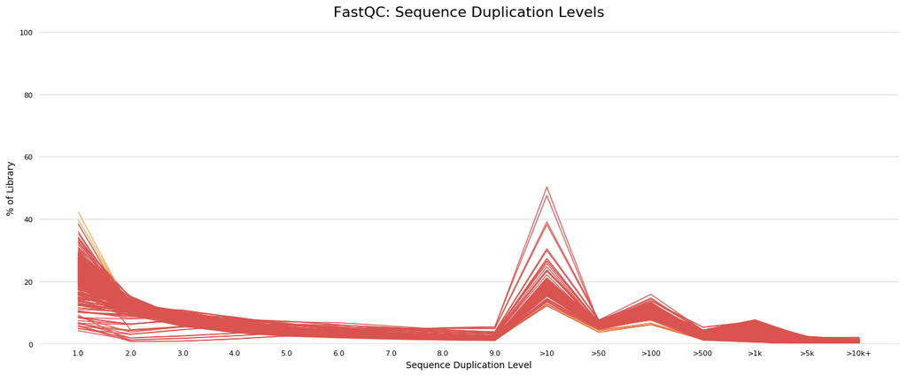

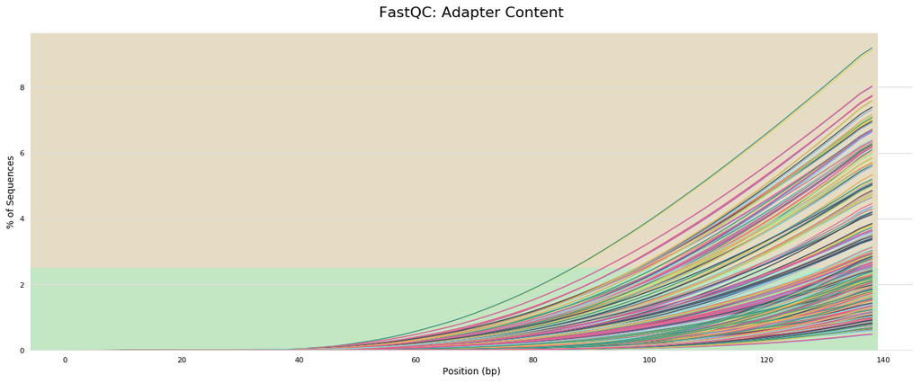

Calidad de las secuencias en muestras SLE

## Conclusión

Los resultados del análisis de calidad muestran que los datos son adecuados para continuar con el procesamiento y análisis posterior. Las secuencias tienen una buena calidad general, con valores de Phred superiores a 30 y un contenido de GC apropiado. Aunque se observa presencia de contaminación, esta será eliminada después del alineamiento. Solo es necesario eliminar las secuencias de rRNA y los adaptadores para optimizar la limpieza de los datos antes de proceder con el análisis final.